# IODS final project, cell morphology study

Sofia Oja (sofia.oja@helsinki.fi)

8 maaliskuuta 2017

## Abstract

Cell biologists have long known that cellular aging in healthy somatic cells, such as mesenchymal stromal cells is manifested - among other characteristics - as increase in cell size. Young mesenchymal stromal cells are known to be small and spindle shaped but become enlarged among extended culturing. Aged and senescent cells are not desired in cell cultures because aging is known to alter cell characteristics and function and may have detrimental effects to the cultures. In this study, we imaged mesenchymal stromal cells using Cell Insight imaging platform (Thermo Scientific, Biomedicum Imaging Unit (BIU)) to measure several morphometric parameters. Our aim was to find the morphometric parameter, which could describe the aging process in mesenchymal stromal cell cultures. The cells were cultured in 6 well culture plates from primary cultures to senescence. Samples for the imaging analysis were collected from passages 1, 3, 5 and 7 (p1, p3, p5 and p7). Findings from my original study are included in research publication and is under review process. All findings included in the submitted paper are excluded from this final assessment. In this final assessment I have used other data collected during this study.

In this study main findings were, that cell perimeter parameter was increasing as function of population doubling number and culture time. Similarly, P2A and ConvexHullAreaRatio protrusions parameters were increasing as function of population doubling number and culture time, however ConvexHullPerimRatio was decreasing as a function of population doubling number and culture time. These findings suggests that the above cell size and shape morphometric parameters could be used to monitor the aging process in cell cultures.

## Research question

In this final assessment, I have analyzed the correlations of parameters describing cell size to parameters describing cell shape. Correlations of these parameters were studied along cell aging. Culture time and population doubling number (PD) were used to describe cellular aging. Population doubling number describes the number of cell divisions during the lifespan of the cell culture.

Hypothesis are

- Cell perimeter increases with cell aging
- Cell protrusions increases with cell aging

## Data wrangling part

Link to data wrangling script https://github.com/sofiaoja/IODS-final/blob/master/create_cell.R.

## Description of data and its variables

The data was collected at Biomedicum Imaging Unit using Cell Insight imaging platform and Cell Omics Morphology Explorer software. Acquisition of the morphometric measurements were done by automated imaging analysis, where the rules for cell detection was set according to several test samples. However, the analysis software was not able in some cases to detect overlapping cells as separate and therefore made misinterpretations of cell sizes.Therefore, at the data wrangling phase, the data from p1 and from parameters ObjectShapeLWRCh1 and ObjectConvexHullAreaRatioCh1 was filtered.

Cell feature parameters (ref. Thermo Fisher Scientific Inc. Cell Insight user manual)

Cell size parameters

- ObjectAreaCh1 (units pixels) = area of the cell, area (in pixels or micrometers^2) of Ch1 object
- ObjectPerimCh1 (units pixels) = perimeter of the cell, perimeter (in pixels or micrometers) of Ch1 object
- ObjectLengthCh1 (units pixels) = Length (in pixels or micrometers) of object-aligned bounding box of Ch1 object
- ObjectWidthCh1 (units pixels) = Width (in pixels or micrometers) of object-aligned bounding box of Ch1 object

Cell shape parameters

- ObjectShapeP2ACh1 (units number) = Shape measure based on ratio of perimeter squared to 4pii*area of Ch1 object (ObjectShapeP2ACh1 = 1 for circular object)
- ObjectShapeLWRCh1 (units number) = Shape measure based on ratio of length to width of object-aligned bounding box of Ch1 object
- ObjectShapeBFRCh1 (units number) = Shape measure based on ratio of object area to box area of object-aligned bounding box of Ch1 object
- ObjectConvexHullAreaRatioCh1 (units number) = Ratio of convex hull area to area of Ch1 object
- ObjectConvexHullPerimRatioCh1 (units number) = Ratio of convex hull perimeter to perimeter of Ch1 object

## Analysis part

Data was analysed using normal distribution, correlation, linear regression model and dimensionality reduction techniques. Detailed results and plots are shown in the last section, here is a short summary of the main findings.

In the correlation analysis, strong positive correlations were found for cell size parameters (e.g. area and perimeter) and strong negative for cell shape parameters (e.g. ConvexHullPerimRatio).

To study the aging process in mesenchymal stromal cell cultures, cell morphometric parameters were plotted as a function of population doubling number and culture time. Main finding for size and shape parameters below.

Size parameters

- Cell perimeter parameter was increasing as function of PD and culture time.

Shape parameters

- P2A and ConvexHullAreaRatio protrusions parameters were increasing as function of PD and culture time, however ConvexHullPerimRatio was decreasing as a function of PD and culture time.

To study the linear behaviour of the parameters and further to use the model for predictions, linear regression model was explored in more detail. The target and the variables for the linear model were selected from the correlation analysis with strong positive correlations, the linear regression model was explaining the cell area as a function of cell perimeter, width and length parameters with high R squared value of the model.

Data was further analysed using dimensionality reduction techniques for a subset of cell features for passages 1, 3, 5 and 7 data (p1, p3, p5 and p7). Similar trends were observed in all passage data.

- ObjectPerimCh1 and ObjectConvexHullPerimRatioCh1 are linear to PC1 and pointing to opposite directions.
- Strong correlations are found between ObjectPerimCh1 and ObjectLengthCh1, ObjectAreaCh1 and ObjectWidthCh1, ObjectShapeP2ACh1 and ObjectConvexHullAreaRatioCh1.
- Cell size and shape parameters correlated mainly together, respectively.
- Similar findings were also obtained from the correlation analysis, thus validating the PCA analysis.

As a summary, these findings suggests that the above cell size and shape morphometric parameters could be used to monitor the aging process in cell cultures.

# Final assignment, cell morphology study

*IODS final project, R script file for Analysis.*

- Data was loaded for further analysis using normal distribution, correlation, linear regression model and dimensionality reduction techniques and results were interpreted.

```r
# set working directory
setwd("C:/Users/Sofia/Documents/Temp/Data example/")

# Access xlsx library
library(xlsx)
# read xlsx into R
p1_006 <- read.xlsx2("p1_006.xlsx",
                     sheetIndex = 1,
                     colIndex = 1,
                     endCol = 10)

p3_006 <- read.xlsx2("p3_006.xlsx",
                     sheetIndex = 1,
                     colIndex = 1,
                     endCol = 10)

p5_006 <- read.xlsx2("p5_006.xlsx",
                     sheetIndex = 1,
                     colIndex = 1,
                     endCol = 10)

p7_006 <- read.xlsx2("p7_006.xlsx",
                     sheetIndex = 1,
                     colIndex = 1,
                     endCol = 10)

# mutate p1_006 parameters to numeric
p1_006$solun.nro <- as.numeric(as.character(p1_006$solun.nro))
p1_006$ObjectAreaCh1 <- as.numeric(as.character(p1_006$ObjectAreaCh1))
p1_006$ObjectPerimCh1 <- as.numeric(as.character(p1_006$ObjectPerimCh1))
p1_006$ObjectShapeP2ACh1 <- as.numeric(as.character(p1_006$ObjectShapeP2ACh1))
p1_006$ObjectShapeLWRCh1 <- as.numeric(as.character(p1_006$ObjectShapeLWRCh1))
p1_006$ObjectShapeBFRCh1 <- as.numeric(as.character(p1_006$ObjectShapeBFRCh1))
p1_006$ObjectLengthCh1 <- as.numeric(as.character(p1_006$ObjectLengthCh1))
p1_006$ObjectWidthCh1 <- as.numeric(as.character(p1_006$ObjectWidthCh1))
p1_006$ObjectConvexHullAreaRatioCh1 <- as.numeric(as.character(p1_006$ObjectConvexHullAreaRatioCh1))
p1_006$ObjectConvexHullPerimRatioCh1 <- as.numeric(as.character(p1_006$ObjectConvexHullPerimRatioCh1))

# mutate p3_006 parameters to numeric
p3_006$solun.nro <- as.numeric(as.character(p3_006$solun.nro))
p3_006$ObjectAreaCh1 <- as.numeric(as.character(p3_006$ObjectAreaCh1))
p3_006$ObjectPerimCh1 <- as.numeric(as.character(p3_006$ObjectPerimCh1))
p3_006$ObjectShapeP2ACh1 <- as.numeric(as.character(p3_006$ObjectShapeP2ACh1))
p3_006$ObjectShapeLWRCh1 <- as.numeric(as.character(p3_006$ObjectShapeLWRCh1))
p3_006$ObjectShapeBFRCh1 <- as.numeric(as.character(p3_006$ObjectShapeBFRCh1))
p3_006$ObjectLengthCh1 <- as.numeric(as.character(p3_006$ObjectLengthCh1))
p3_006$ObjectWidthCh1 <- as.numeric(as.character(p3_006$ObjectWidthCh1))
p3_006$ObjectConvexHullAreaRatioCh1 <- as.numeric(as.character(p3_006$ObjectConvexHullAreaRatioCh1))
p3_006$ObjectConvexHullPerimRatioCh1 <- as.numeric(as.character(p3_006$ObjectConvexHullPerimRatioCh1))

# mutate p5_006 parameters to numeric
p5_006$solun.nro <- as.numeric(as.character(p5_006$solun.nro))
p5_006$ObjectAreaCh1 <- as.numeric(as.character(p5_006$ObjectAreaCh1))
p5_006$ObjectPerimCh1 <- as.numeric(as.character(p5_006$ObjectPerimCh1))
p5_006$ObjectShapeP2ACh1 <- as.numeric(as.character(p5_006$ObjectShapeP2ACh1))
p5_006$ObjectShapeLWRCh1 <- as.numeric(as.character(p5_006$ObjectShapeLWRCh1))
p5_006$ObjectShapeBFRCh1 <- as.numeric(as.character(p5_006$ObjectShapeBFRCh1))
p5_006$ObjectLengthCh1 <- as.numeric(as.character(p5_006$ObjectLengthCh1))
p5_006$ObjectWidthCh1 <- as.numeric(as.character(p5_006$ObjectWidthCh1))
p5_006$ObjectConvexHullAreaRatioCh1 <- as.numeric(as.character(p5_006$ObjectConvexHullAreaRatioCh1))
p5_006$ObjectConvexHullPerimRatioCh1 <- as.numeric(as.character(p5_006$ObjectConvexHullPerimRatioCh1))

# mutate p7_006 parameters to numeric
p7_006$solun.nro <- as.numeric(as.character(p7_006$solun.nro))
p7_006$ObjectAreaCh1 <- as.numeric(as.character(p7_006$ObjectAreaCh1))
p7_006$ObjectPerimCh1 <- as.numeric(as.character(p7_006$ObjectPerimCh1))
p7_006$ObjectShapeP2ACh1 <- as.numeric(as.character(p7_006$ObjectShapeP2ACh1))
p7_006$ObjectShapeLWRCh1 <- as.numeric(as.character(p7_006$ObjectShapeLWRCh1))
p7_006$ObjectShapeBFRCh1 <- as.numeric(as.character(p7_006$ObjectShapeBFRCh1))
p7_006$ObjectLengthCh1 <- as.numeric(as.character(p7_006$ObjectLengthCh1))
p7_006$ObjectWidthCh1 <- as.numeric(as.character(p7_006$ObjectWidthCh1))
p7_006$ObjectConvexHullAreaRatioCh1 <- as.numeric(as.character(p7_006$ObjectConvexHullAreaRatioCh1))
p7_006$ObjectConvexHullPerimRatioCh1 <- as.numeric(as.character(p7_006$ObjectConvexHullPerimRatioCh1))

# stucture of the new dataset
#str(p1_006)
dim(p1_006)
```

```
## [1] 8523   11
```

```r
summary(p1_006)
```

```
##    solun.nro    ObjectAreaCh1   ObjectPerimCh1   ObjectShapeP2ACh1
##  Min.   :   1   Min.   :  460   Min.   : 82.77   Min.   : 1.106
##  1st Qu.:2138   1st Qu.:  692   1st Qu.:131.74   1st Qu.: 1.729
##  Median :4272   Median :  880   Median :158.75   Median : 2.119
##  Mean   :4272   Mean   : 1045   Mean   :171.27   Mean   : 2.313
##  3rd Qu.:6404   3rd Qu.: 1178   3rd Qu.:194.75   3rd Qu.: 2.683
##  Max.   :8542   Max.   :10674   Max.   :802.29   Max.   :12.176
##  ObjectShapeLWRCh1 ObjectShapeBFRCh1 ObjectLengthCh1  ObjectWidthCh1
##  Min.   :1.001     Min.   :0.1565    Min.   : 26.71   Min.   : 10.91
##  1st Qu.:1.657     1st Qu.:0.5060    1st Qu.: 49.14   1st Qu.: 21.61
##  Median :2.199     Median :0.5739    Median : 60.80   Median : 26.64
##  Mean   :2.457     Mean   :0.5662    Mean   : 65.07   Mean   : 28.99
##  3rd Qu.:2.997     3rd Qu.:0.6365    3rd Qu.: 75.92   3rd Qu.: 33.41
##  Max.   :9.983     Max.   :0.8639    Max.   :244.96   Max.   :125.32
##  ObjectConvexHullAreaRatioCh1 ObjectConvexHullPerimRatioCh1    startRow
##  Min.   :1.011                Min.   :0.6457                Min.   :1
##  1st Qu.:1.118                1st Qu.:0.9024                1st Qu.:1
##  Median :1.190                Median :0.9292                Median :1
##  Mean   :1.238                Mean   :0.9176                Mean   :1
##  3rd Qu.:1.300                3rd Qu.:0.9445                3rd Qu.:1
##  Max.   :3.456                Max.   :0.9765                Max.   :1
```

```r
dim(p3_006)
```

```
## [1] 3258   11
```

```r
summary(p3_006)
```

```
##    solun.nro      ObjectAreaCh1  ObjectPerimCh1    ObjectShapeP2ACh1
##  Min.   :   1.0   Min.   : 460   Min.   :  83.36   Min.   : 1.129
##  1st Qu.: 815.2   1st Qu.: 688   1st Qu.: 127.89   1st Qu.: 1.660
##  Median :1629.5   Median : 905   Median : 158.12   Median : 2.103
##  Mean   :1629.5   Mean   :1107   Mean   : 179.47   Mean   : 2.385
##  3rd Qu.:2443.8   3rd Qu.:1264   3rd Qu.: 204.14   3rd Qu.: 2.773
##  Max.   :3258.0   Max.   :9694   Max.   :1146.04   Max.   :13.987
##  ObjectShapeLWRCh1 ObjectShapeBFRCh1 ObjectLengthCh1  ObjectWidthCh1
##  Min.   : 1.003    Min.   :0.1426    Min.   : 27.31   Min.   : 10.04
##  1st Qu.: 1.611    1st Qu.:0.5033    1st Qu.: 46.94   1st Qu.: 22.17
##  Median : 2.128    Median :0.5827    Median : 60.17   Median : 26.84
##  Mean   : 2.443    Mean   :0.5695    Mean   : 67.13   Mean   : 29.97
##  3rd Qu.: 2.941    3rd Qu.:0.6483    3rd Qu.: 78.50   3rd Qu.: 33.89
##  Max.   :11.699    Max.   :0.8377    Max.   :261.94   Max.   :181.24
##  ObjectConvexHullAreaRatioCh1 ObjectConvexHullPerimRatioCh1    startRow
##  Min.   :1.015                Min.   :0.5498                Min.   :1
##  1st Qu.:1.106                1st Qu.:0.8988                1st Qu.:1
##  Median :1.182                Median :0.9284                Median :1
##  Mean   :1.250                Mean   :0.9127                Mean   :1
##  3rd Qu.:1.317                3rd Qu.:0.9451                3rd Qu.:1
##  Max.   :3.906                Max.   :0.9804                Max.   :1
```

```r
dim(p5_006)
```

```
## [1] 2190   11
```

```r
summary(p5_006)
```

```
##    solun.nro      ObjectAreaCh1   ObjectPerimCh1    ObjectShapeP2ACh1
##  Min.   :   1.0   Min.   :  468   Min.   :  84.28   Min.   : 1.109
##  1st Qu.: 548.2   1st Qu.: 1340   1st Qu.: 191.46   1st Qu.: 1.888
##  Median :1095.5   Median : 2041   Median : 274.49   Median : 2.658
##  Mean   :1095.5   Mean   : 2728   Mean   : 317.42   Mean   : 3.201
##  3rd Qu.:1642.8   3rd Qu.: 3392   3rd Qu.: 396.79   3rd Qu.: 3.905
##  Max.   :2190.0   Max.   :29454   Max.   :1587.78   Max.   :16.162
##  ObjectShapeLWRCh1 ObjectShapeBFRCh1 ObjectLengthCh1  ObjectWidthCh1
##  Min.   : 1.001    Min.   :0.1088    Min.   : 28.08   Min.   : 13.90
##  1st Qu.: 1.551    1st Qu.:0.4082    1st Qu.: 68.78   1st Qu.: 31.38
##  Median : 2.080    Median :0.5077    Median :100.32   Median : 43.15
##  Mean   : 2.488    Mean   :0.5036    Mean   :111.95   Mean   : 50.14
##  3rd Qu.: 2.909    3rd Qu.:0.6071    3rd Qu.:141.66   3rd Qu.: 60.98
##  Max.   :13.566    Max.   :0.8235    Max.   :451.31   Max.   :209.81
##  ObjectConvexHullAreaRatioCh1 ObjectConvexHullPerimRatioCh1    startRow
##  Min.   :1.013                Min.   :0.4675                Min.   :1
##  1st Qu.:1.166                1st Qu.:0.8462                1st Qu.:1
##  Median :1.311                Median :0.8998                Median :1
##  Mean   :1.422                Mean   :0.8778                Mean   :1
##  3rd Qu.:1.543                3rd Qu.:0.9304                3rd Qu.:1
##  Max.   :5.060                Max.   :0.9742                Max.   :1
```

```r
dim(p7_006)
```

```
## [1] 2082   11
```

```r
summary(p7_006)
```

```
##    solun.nro      ObjectAreaCh1   ObjectPerimCh1    ObjectShapeP2ACh1
##  Min.   :   1.0   Min.   :  461   Min.   :  86.67   Min.   : 1.112
##  1st Qu.: 521.2   1st Qu.: 2884   1st Qu.: 328.26   1st Qu.: 2.304
##  Median :1041.5   Median : 4867   Median : 461.62   Median : 3.238
##  Mean   :1041.5   Mean   : 6150   Mean   : 506.90   Mean   : 3.831
##  3rd Qu.:1561.8   3rd Qu.: 8198   3rd Qu.: 642.71   3rd Qu.: 4.639
##  Max.   :2082.0   Max.   :40106   Max.   :2602.24   Max.   :21.898
##  ObjectShapeLWRCh1 ObjectShapeBFRCh1 ObjectLengthCh1  ObjectWidthCh1
##  Min.   : 1.000    Min.   :0.09691   Min.   : 27.14   Min.   : 13.40
##  1st Qu.: 1.450    1st Qu.:0.37854   1st Qu.:109.72   1st Qu.: 51.39
##  Median : 1.881    Median :0.47196   Median :150.74   Median : 75.16
##  Mean   : 2.236    Mean   :0.47074   Mean   :160.32   Mean   : 81.12
##  3rd Qu.: 2.571    3rd Qu.:0.56666   3rd Qu.:198.64   3rd Qu.:103.78
##  Max.   :15.109    Max.   :0.82502   Max.   :480.85   Max.   :309.26
##  ObjectConvexHullAreaRatioCh1 ObjectConvexHullPerimRatioCh1    startRow
##  Min.   :1.012                Min.   :0.3887                Min.   :1
##  1st Qu.:1.237                1st Qu.:0.7573                1st Qu.:1
##  Median :1.411                Median :0.8260                Median :1
##  Mean   :1.540                Mean   :0.8144                Mean   :1
##  3rd Qu.:1.704                3rd Qu.:0.8831                3rd Qu.:1
##  Max.   :5.223                Max.   :0.9759                Max.   :1
```

```r
# access the tidyverse libraries tidyr, dplyr
library(tidyr); library(dplyr)
# clean columns
p1_006 <- select(p1_006, -startRow)
p3_006 <- select(p3_006, -startRow)
p5_006 <- select(p5_006, -startRow)
p7_006 <- select(p7_006, -startRow)

# clean columns
p1_006 <- select(p1_006, -solun.nro)
p3_006 <- select(p3_006, -solun.nro)
p5_006 <- select(p5_006, -solun.nro)
p7_006 <- select(p7_006, -solun.nro)
```

Normal distributions and correlations between the parameters were studied for passage 1 data (p1).

Parameters resembling normal distribution mainly for ObjectShapeBFRCh1 variable, other parameters have shifted distributions.

Strong correlations between

- ObjectAreaCh1 and ObjectPerimCh1 (0.838)
- ObjectAreaCh1 and ObjectLengthCh1 (0.698)
- ObjectAreaCh1 and ObjectWidthCh1 (0.783)
- ObjectPerimCh1 and ObjectShapeP2ACh1 (0.694)
- ObjectPerimCh1 and ObjectLengthCh1 (0.934)
- ObjectPerimCh1 and ObjectWidthCh1 (0.610)
- ObjectPerimCh1 and ObjectConvexHullAreaRatioCh1 (0.637)

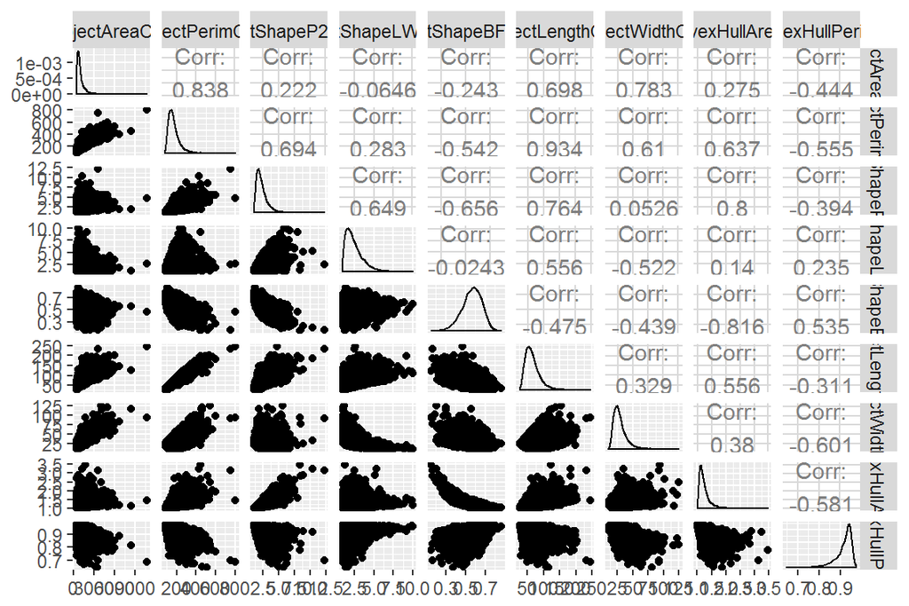

```r
# access the GGally and ggplot2 libraries
library(GGally)
library(ggplot2)

# advanced plot matrix with ggpairs()
ggpairs(p1_006, mapping = aes(), lower = list(combo = wrap("facethist", bins = 20)))
```

```r
# Cumulative PD and Day parameter table
PD = c(19.8, 31.3, 40.0, 45.9)
Day = c(15, 28, 42, 78)

# Cell size parameters

# mean and standard deviation of cell ObjectAreaCh1 parameter
mean_p1_006_ObjectAreaCh1 = mean(p1_006$ObjectAreaCh1)
sd_p1_006_ObjectAreaCh1 =sd(p1_006$ObjectAreaCh1)

mean_p3_006_ObjectAreaCh1 = mean(p3_006$ObjectAreaCh1)
sd_p3_006_ObjectAreaCh1 =sd(p3_006$ObjectAreaCh1)

mean_p5_006_ObjectAreaCh1 = mean(p5_006$ObjectAreaCh1)
sd_p5_006_ObjectAreaCh1 =sd(p5_006$ObjectAreaCh1)

mean_p7_006_ObjectAreaCh1 = mean(p7_006$ObjectAreaCh1)
sd_p7_006_ObjectAreaCh1 =sd(p7_006$ObjectAreaCh1)

# mean and standard deviation of cell ObjectPerimCh1 parameter
mean_p1_006_ObjectPerimCh1 = mean(p1_006$ObjectPerimCh1)
sd_p1_006_ObjectPerimCh1 =sd(p1_006$ObjectPerimCh1)

mean_p3_006_ObjectPerimCh1 = mean(p3_006$ObjectPerimCh1)
sd_p3_006_ObjectPerimCh1 =sd(p3_006$ObjectPerimCh1)

mean_p5_006_ObjectPerimCh1 = mean(p5_006$ObjectPerimCh1)
sd_p5_006_ObjectPerimCh1 =sd(p5_006$ObjectPerimCh1)

mean_p7_006_ObjectPerimCh1 = mean(p7_006$ObjectPerimCh1)
sd_p7_006_ObjectPerimCh1 =sd(p7_006$ObjectPerimCh1)

# Cell shape parameters

# mean and standard deviation of cell ObjectShapeP2ACh1 parameter
mean_p1_006_ObjectShapeP2ACh1 = mean(p1_006$ObjectShapeP2ACh1)
sd_p1_006_ObjectShapeP2ACh1 =sd(p1_006$ObjectShapeP2ACh1)

mean_p3_006_ObjectShapeP2ACh1 = mean(p3_006$ObjectShapeP2ACh1)
sd_p3_006_ObjectShapeP2ACh1 =sd(p3_006$ObjectShapeP2ACh1)

mean_p5_006_ObjectShapeP2ACh1 = mean(p5_006$ObjectShapeP2ACh1)
sd_p5_006_ObjectShapeP2ACh1 =sd(p5_006$ObjectShapeP2ACh1)

mean_p7_006_ObjectShapeP2ACh1 = mean(p7_006$ObjectShapeP2ACh1)
sd_p7_006_ObjectShapeP2ACh1 =sd(p7_006$ObjectShapeP2ACh1)

# mean and standard deviation of cell ObjectConvexHullAreaRatioCh1 parameter
mean_p1_006_ObjectConvexHullAreaRatioCh1 = mean(p1_006$ObjectConvexHullAreaRatioCh1)
sd_p1_006_ObjectConvexHullAreaRatioCh1 =sd(p1_006$ObjectConvexHullAreaRatioCh1)

mean_p3_006_ObjectConvexHullAreaRatioCh1 = mean(p3_006$ObjectConvexHullAreaRatioCh1)
sd_p3_006_ObjectConvexHullAreaRatioCh1 =sd(p3_006$ObjectConvexHullAreaRatioCh1)

mean_p5_006_ObjectConvexHullAreaRatioCh1 = mean(p5_006$ObjectConvexHullAreaRatioCh1)
sd_p5_006_ObjectConvexHullAreaRatioCh1 =sd(p5_006$ObjectConvexHullAreaRatioCh1)

mean_p7_006_ObjectConvexHullAreaRatioCh1 = mean(p7_006$ObjectConvexHullAreaRatioCh1)
sd_p7_006_ObjectConvexHullAreaRatioCh1 =sd(p7_006$ObjectConvexHullAreaRatioCh1)

# mean and standard deviation of cell ObjectConvexHullPerimRatioCh1 parameter
mean_p1_006_ObjectConvexHullPerimRatioCh1 = mean(p1_006$ObjectConvexHullPerimRatioCh1)
sd_p1_006_ObjectConvexHullPerimRatioCh1 =sd(p1_006$ObjectConvexHullPerimRatioCh1)

mean_p3_006_ObjectConvexHullPerimRatioCh1 = mean(p3_006$ObjectConvexHullPerimRatioCh1)
sd_p3_006_ObjectConvexHullPerimRatioCh1 =sd(p3_006$ObjectConvexHullPerimRatioCh1)

mean_p5_006_ObjectConvexHullPerimRatioCh1 = mean(p5_006$ObjectConvexHullPerimRatioCh1)
sd_p5_006_ObjectConvexHullPerimRatioCh1 =sd(p5_006$ObjectConvexHullPerimRatioCh1)

mean_p7_006_ObjectConvexHullPerimRatioCh1 = mean(p7_006$ObjectConvexHullPerimRatioCh1)
sd_p7_006_ObjectConvexHullPerimRatioCh1 =sd(p7_006$ObjectConvexHullPerimRatioCh1)

# Cell size parameters

# Mean and standard deviation table ObjectAreaCh1
mean_p1357_006_ObjectAreaCh1 = c(mean_p1_006_ObjectAreaCh1, mean_p3_006_ObjectAreaCh1, mean_p5_006_ObjectAreaCh1, mean_p7_006_ObjectAreaCh1)
sd_p1357_006_ObjectAreaCh1 = c(sd_p1_006_ObjectAreaCh1, sd_p3_006_ObjectAreaCh1, sd_p5_006_ObjectAreaCh1, sd_p7_006_ObjectAreaCh1)

# Mean and standard deviation table ObjectPerimCh1
mean_p1357_006_ObjectPerimCh1 = c(mean_p1_006_ObjectPerimCh1, mean_p3_006_ObjectPerimCh1, mean_p5_006_ObjectPerimCh1, mean_p7_006_ObjectPerimCh1)
sd_p1357_006_ObjectPerimCh1 = c(sd_p1_006_ObjectPerimCh1, sd_p3_006_ObjectPerimCh1, sd_p5_006_ObjectPerimCh1, sd_p7_006_ObjectPerimCh1)

# Cell shape parameters

# Mean and standard deviation table ObjectShapeP2ACh1
mean_p1357_006_ObjectShapeP2ACh1 = c(mean_p1_006_ObjectShapeP2ACh1, mean_p3_006_ObjectShapeP2ACh1, mean_p5_006_ObjectShapeP2ACh1, mean_p7_006_ObjectShapeP2ACh1)
sd_p1357_006_ObjectShapeP2ACh1 = c(sd_p1_006_ObjectShapeP2ACh1, sd_p3_006_ObjectShapeP2ACh1, sd_p5_006_ObjectShapeP2ACh1, sd_p7_006_ObjectShapeP2ACh1)

# Mean and standard deviation table ObjectConvexHullAreaRatioCh1
mean_p1357_006_ObjectConvexHullAreaRatioCh1 = c(mean_p1_006_ObjectConvexHullAreaRatioCh1, mean_p3_006_ObjectConvexHullAreaRatioCh1, mean_p5_006_ObjectConvexHullAreaRatioCh1, mean_p7_006_ObjectConvexHullAreaRatioCh1)
sd_p1357_006_ObjectConvexHullAreaRatioCh1 = c(sd_p1_006_ObjectConvexHullAreaRatioCh1, sd_p3_006_ObjectConvexHullAreaRatioCh1, sd_p5_006_ObjectConvexHullAreaRatioCh1, sd_p7_006_ObjectConvexHullAreaRatioCh1)

# Mean and standard deviation table ObjectConvexHullPerimRatioCh1
mean_p1357_006_ObjectConvexHullPerimRatioCh1 = c(mean_p1_006_ObjectConvexHullPerimRatioCh1, mean_p3_006_ObjectConvexHullPerimRatioCh1, mean_p5_006_ObjectConvexHullPerimRatioCh1, mean_p7_006_ObjectConvexHullPerimRatioCh1)
sd_p1357_006_ObjectConvexHullPerimRatioCh1 = c(sd_p1_006_ObjectConvexHullPerimRatioCh1, sd_p3_006_ObjectConvexHullPerimRatioCh1, sd_p5_006_ObjectConvexHullPerimRatioCh1, sd_p7_006_ObjectConvexHullPerimRatioCh1)

# Create data.frame for data
table_p1357_ObjectAreaCh1 <- data.frame(PopulationDoubling = PD,
                  CultureTime = Day,
                  mean_ObjectAreaCh1 = mean_p1357_006_ObjectAreaCh1,
                  sd_ObjectAreaCh1 = sd_p1357_006_ObjectAreaCh1)

table_p1357_ObjectPerimCh1 <- data.frame(PopulationDoubling = PD,
                          CultureTime = Day,
                          mean_ObjectPerimCh1 = mean_p1357_006_ObjectPerimCh1,
                          sd_ObjectPerimCh1 = sd_p1357_006_ObjectPerimCh1)

table_p1357_ObjectShapeP2ACh1 <- data.frame(PopulationDoubling = PD,
                          CultureTime = Day,
                          mean_ObjectShapeP2ACh1 = mean_p1357_006_ObjectShapeP2ACh1,
                          sd_ObjectShapeP2ACh1 = sd_p1357_006_ObjectShapeP2ACh1)

table_p1357_ObjectConvexHullAreaRatioCh1 <- data.frame(PopulationDoubling = PD,
                          CultureTime = Day,
                          mean_ObjectConvexHullAreaRatioCh1 = mean_p1357_006_ObjectConvexHullAreaRatioCh1,
                          sd_ObjectConvexHullAreaRatioCh1 = sd_p1357_006_ObjectConvexHullAreaRatioCh1)

table_p1357_ObjectConvexHullPerimRatioCh1 <- data.frame(PopulationDoubling = PD,
                          CultureTime = Day,
                          mean_ObjectConvexHullPerimRatioCh1 = mean_p1357_006_ObjectConvexHullPerimRatioCh1,
                          sd_ObjectConvexHullPerimRatioCh1 = sd_p1357_006_ObjectConvexHullPerimRatioCh1)
```

ObjectPerimCh1 parameter was plotted against PD (Population Doubling), cell perimeter is increasing as a function of PD.

ObjectPerimCh1 parameter was plotted against Culture Time (Days), cell perimeter is increasing as a function of Culture Time.

ObjectShapeP2ACh1 parameter was plotted against PD (Population Doubling), cell P2A is increasing as a function of PD.

ObjectShapeP2ACh1 parameter was plotted against Culture Time (Days), cell P2A is increasing as a function of Culture Time.

ObjectConvexHullAreaRatioCh1 parameter was plotted against PD (Population Doubling), cell ConvexHullAreaRatio is increasing as a function of PD.

ObjectConvexHullAreaRatioCh1 parameter was plotted against Culture Time (Days), cell ConvexHullAreaRatio is increasing as a function of Culture Time.

ObjectConvexHullPerimRatioCh1 parameter was plotted against PD (Population Doubling), cell ConvexHullPerimRatio is decreasing as a function of PD.

ObjectConvexHullPerimRatioCh1 parameter was plotted against Culture Time (Days), cell ConvexHullPerimRatio is decreasing as a function of Culture Time.

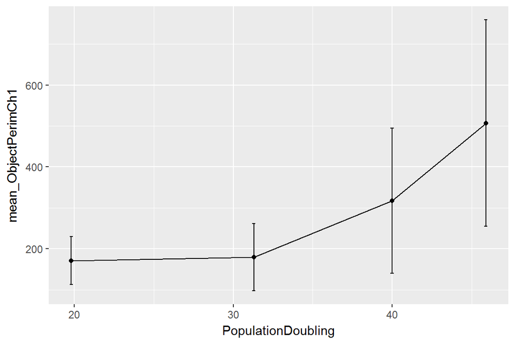

```r
# Draw plots
# ggplot(table_p1357_ObjectAreaCh1, aes(x=PopulationDoubling, y=mean_ObjectAreaCh1)) +
#   geom_errorbar(aes(ymin=mean_ObjectAreaCh1-sd_ObjectAreaCh1, ymax=mean_ObjectAreaCh1+sd_ObjectAreaCh1), width=.2) +
#   geom_line() +
#   geom_point()
#
# ggplot(table_p1357_ObjectAreaCh1, aes(x=CultureTime, y=mean_ObjectAreaCh1)) +
#   geom_errorbar(aes(ymin=mean_ObjectAreaCh1-sd_ObjectAreaCh1, ymax=mean_ObjectAreaCh1+sd_ObjectAreaCh1), width=.2) +
#   geom_line() +
#   geom_point()

ggplot(table_p1357_ObjectPerimCh1, aes(x=PopulationDoubling, y=mean_ObjectPerimCh1)) +
  geom_errorbar(aes(ymin=mean_ObjectPerimCh1-sd_ObjectPerimCh1, ymax=mean_ObjectPerimCh1+sd_ObjectPerimCh1), width=.2) +
  geom_line() +
  geom_point()
```

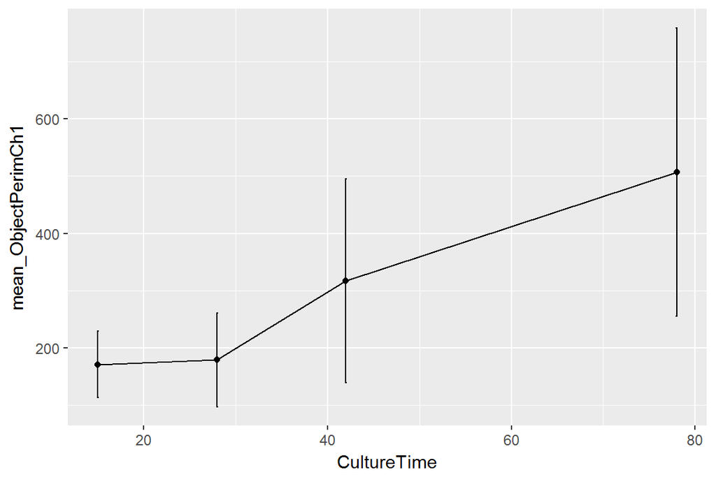

```r
ggplot(table_p1357_ObjectPerimCh1, aes(x=CultureTime, y=mean_ObjectPerimCh1)) +
  geom_errorbar(aes(ymin=mean_ObjectPerimCh1-sd_ObjectPerimCh1, ymax=mean_ObjectPerimCh1+sd_ObjectPerimCh1), width=.2) +
  geom_line() +
  geom_point()
```

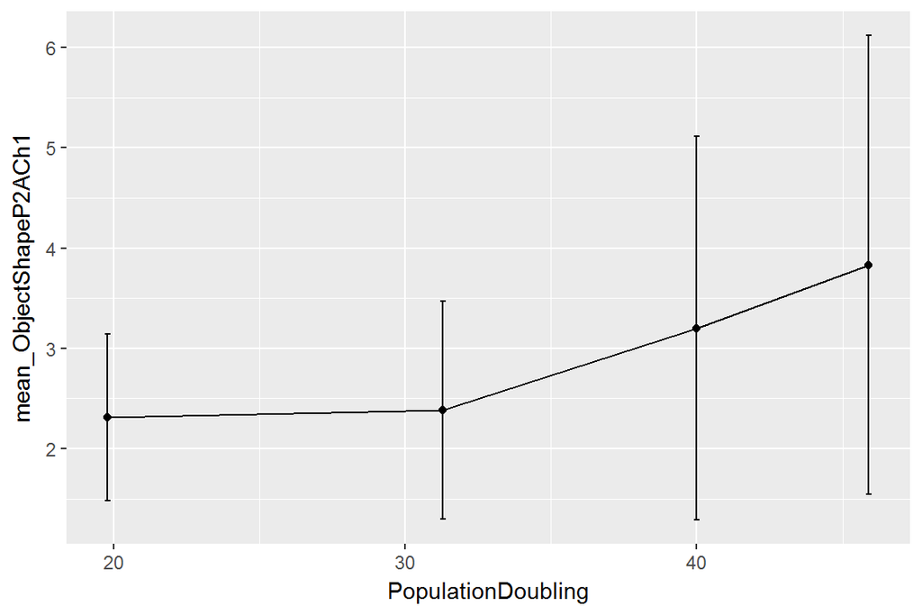

```r
ggplot(table_p1357_ObjectShapeP2ACh1, aes(x=PopulationDoubling, y=mean_ObjectShapeP2ACh1)) +
  geom_errorbar(aes(ymin=mean_ObjectShapeP2ACh1-sd_ObjectShapeP2ACh1, ymax=mean_ObjectShapeP2ACh1+sd_ObjectShapeP2ACh1), width=.2) +
  geom_line() +
  geom_point()
```

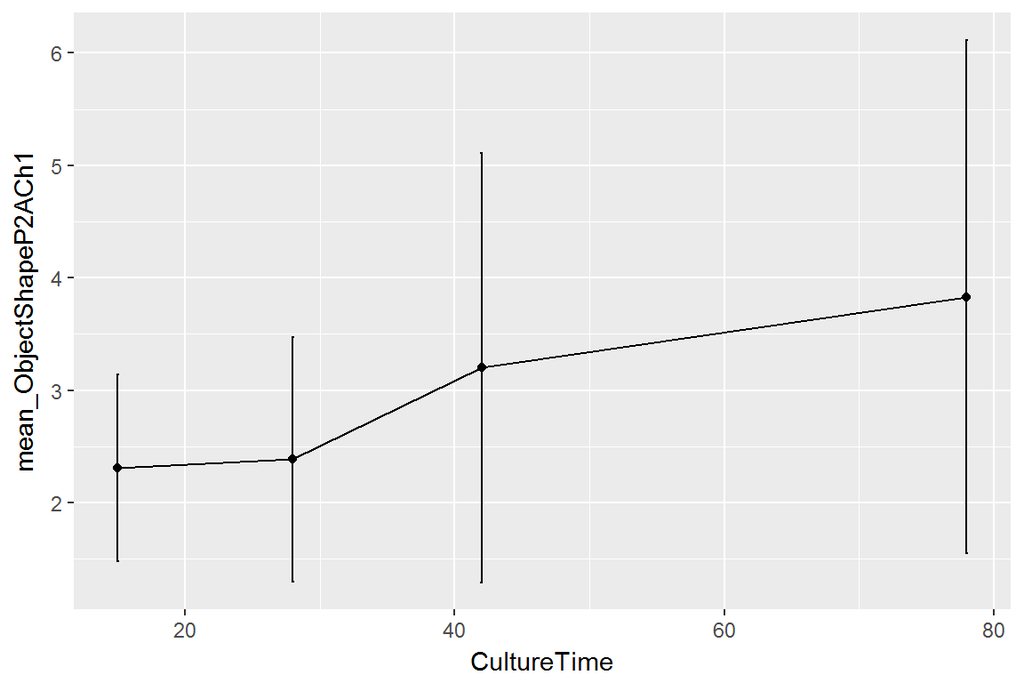

```r
ggplot(table_p1357_ObjectShapeP2ACh1, aes(x=CultureTime, y=mean_ObjectShapeP2ACh1)) +
  geom_errorbar(aes(ymin=mean_ObjectShapeP2ACh1-sd_ObjectShapeP2ACh1, ymax=mean_ObjectShapeP2ACh1+sd_ObjectShapeP2ACh1), width=.2) +
  geom_line() +
  geom_point()
```

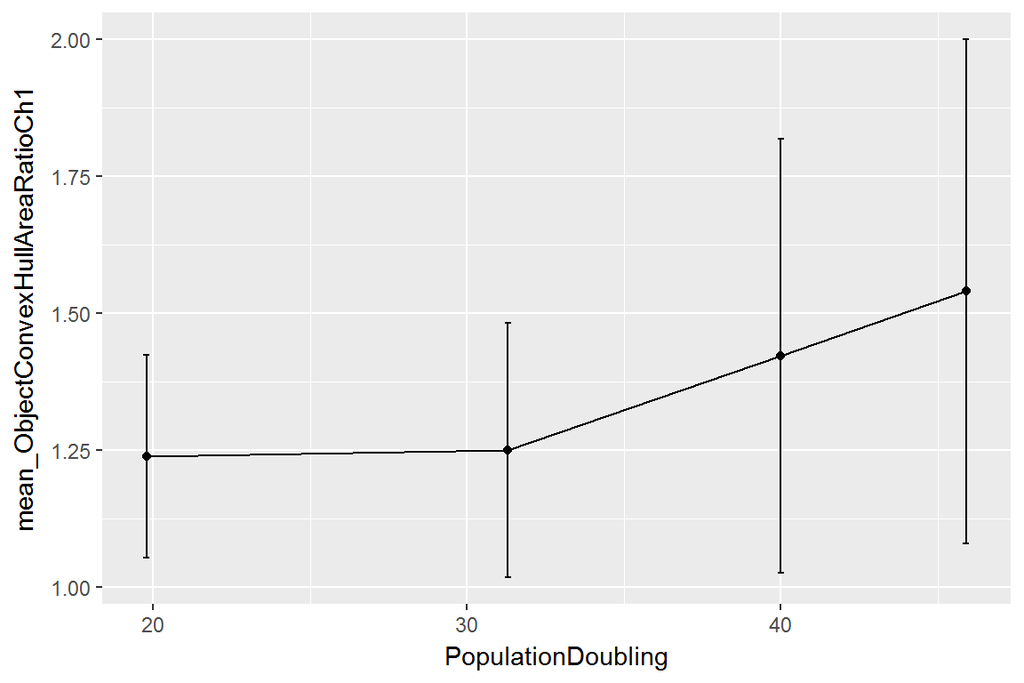

```r
ggplot(table_p1357_ObjectConvexHullAreaRatioCh1, aes(x=PopulationDoubling, y=mean_ObjectConvexHullAreaRatioCh1)) +
  geom_errorbar(aes(ymin=mean_ObjectConvexHullAreaRatioCh1-sd_ObjectConvexHullAreaRatioCh1, ymax=mean_ObjectConvexHullAreaRatioCh1+sd_ObjectConvexHullAreaRatioCh1), width=.2) +
  geom_line() +
  geom_point()
```

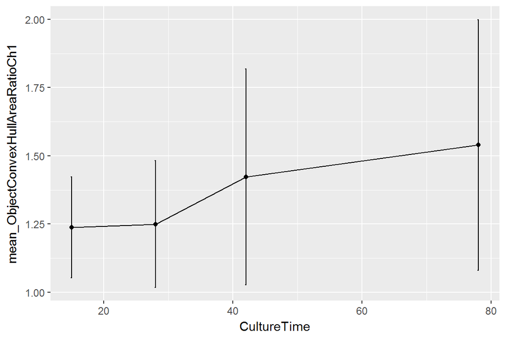

```r
ggplot(table_p1357_ObjectConvexHullAreaRatioCh1, aes(x=CultureTime, y=mean_ObjectConvexHullAreaRatioCh1)) +
  geom_errorbar(aes(ymin=mean_ObjectConvexHullAreaRatioCh1-sd_ObjectConvexHullAreaRatioCh1, ymax=mean_ObjectConvexHullAreaRatioCh1+sd_ObjectConvexHullAreaRatioCh1), width=.2) +
  geom_line() +
  geom_point()
```

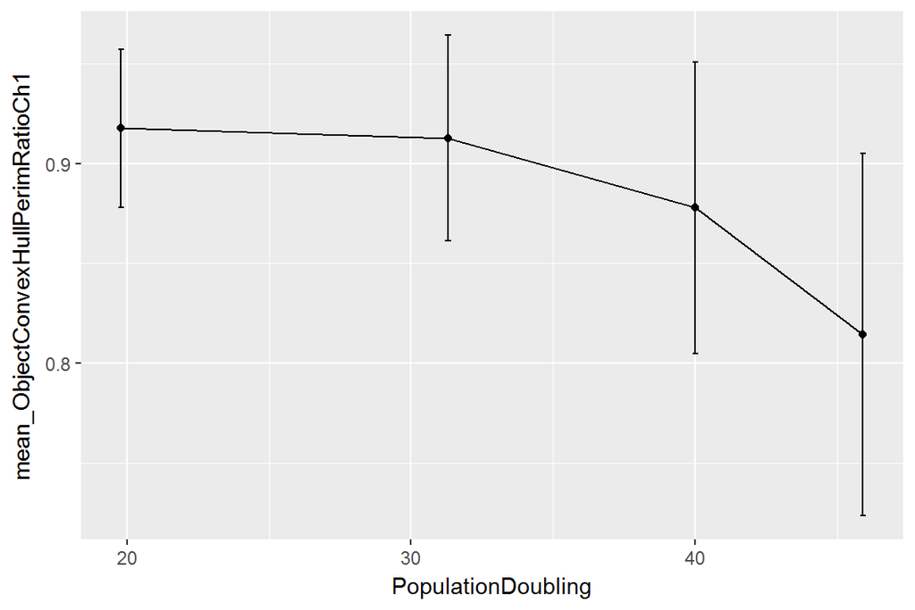

```r
ggplot(table_p1357_ObjectConvexHullPerimRatioCh1, aes(x=PopulationDoubling, y=mean_ObjectConvexHullPerimRatioCh1)) +
  geom_errorbar(aes(ymin=mean_ObjectConvexHullPerimRatioCh1-sd_ObjectConvexHullPerimRatioCh1, ymax=mean_ObjectConvexHullPerimRatioCh1+sd_ObjectConvexHullPerimRatioCh1), width=.2) +
  geom_line() +
  geom_point()
```

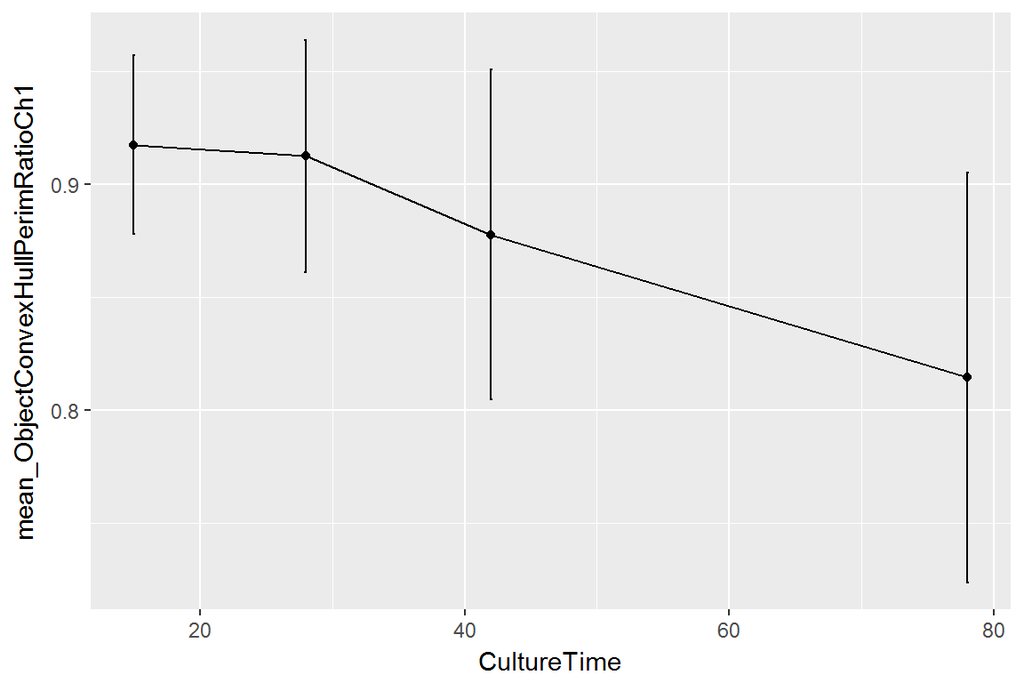

```r
ggplot(table_p1357_ObjectConvexHullPerimRatioCh1, aes(x=CultureTime, y=mean_ObjectConvexHullPerimRatioCh1)) +
  geom_errorbar(aes(ymin=mean_ObjectConvexHullPerimRatioCh1-sd_ObjectConvexHullPerimRatioCh1, ymax=mean_ObjectConvexHullPerimRatioCh1+sd_ObjectConvexHullPerimRatioCh1), width=.2) +
  geom_line() +
  geom_point()
```

```r
# calculate the correlation matrix and round it
cor_matrix_p1_006 <- cor(p1_006)
cor_matrix_p3_006 <- cor(p3_006)
cor_matrix_p5_006 <- cor(p5_006)
cor_matrix_p7_006 <- cor(p7_006)

# print the correlation matrix
cor_matrix_p1_006 %>% round(digits = 2)
```

```
##                               ObjectAreaCh1 ObjectPerimCh1
## ObjectAreaCh1                          1.00           0.84
## ObjectPerimCh1                         0.84           1.00
## ObjectShapeP2ACh1                      0.22           0.69
## ObjectShapeLWRCh1                     -0.06           0.28
## ObjectShapeBFRCh1                     -0.24          -0.54
## ObjectLengthCh1                        0.70           0.93
## ObjectWidthCh1                         0.78           0.61
## ObjectConvexHullAreaRatioCh1           0.28           0.64
## ObjectConvexHullPerimRatioCh1         -0.44          -0.56
##                               ObjectShapeP2ACh1 ObjectShapeLWRCh1
## ObjectAreaCh1                              0.22             -0.06
## ObjectPerimCh1                             0.69              0.28
## ObjectShapeP2ACh1                          1.00              0.65
## ObjectShapeLWRCh1                          0.65              1.00
## ObjectShapeBFRCh1                         -0.66             -0.02
## ObjectLengthCh1                            0.76              0.56
## ObjectWidthCh1                             0.05             -0.52
## ObjectConvexHullAreaRatioCh1               0.80              0.14
## ObjectConvexHullPerimRatioCh1             -0.39              0.23
##                               ObjectShapeBFRCh1 ObjectLengthCh1
## ObjectAreaCh1                             -0.24            0.70
## ObjectPerimCh1                            -0.54            0.93
## ObjectShapeP2ACh1                         -0.66            0.76
## ObjectShapeLWRCh1                         -0.02            0.56
## ObjectShapeBFRCh1                          1.00           -0.48
## ObjectLengthCh1                           -0.48            1.00
## ObjectWidthCh1                            -0.44            0.33
## ObjectConvexHullAreaRatioCh1              -0.82            0.56
## ObjectConvexHullPerimRatioCh1              0.54           -0.31
##                               ObjectWidthCh1 ObjectConvexHullAreaRatioCh1
## ObjectAreaCh1                           0.78                         0.28
## ObjectPerimCh1                          0.61                         0.64
## ObjectShapeP2ACh1                       0.05                         0.80
## ObjectShapeLWRCh1                      -0.52                         0.14
## ObjectShapeBFRCh1                      -0.44                        -0.82
## ObjectLengthCh1                         0.33                         0.56
## ObjectWidthCh1                          1.00                         0.38
## ObjectConvexHullAreaRatioCh1            0.38                         1.00
## ObjectConvexHullPerimRatioCh1          -0.60                        -0.58
##                               ObjectConvexHullPerimRatioCh1
## ObjectAreaCh1                                         -0.44
## ObjectPerimCh1                                        -0.56
## ObjectShapeP2ACh1                                     -0.39
## ObjectShapeLWRCh1                                      0.23
## ObjectShapeBFRCh1                                      0.54
## ObjectLengthCh1                                       -0.31
## ObjectWidthCh1                                        -0.60
## ObjectConvexHullAreaRatioCh1                          -0.58
## ObjectConvexHullPerimRatioCh1                          1.00
```

```r
cor_matrix_p3_006 %>% round(digits = 2)
```

```
##                               ObjectAreaCh1 ObjectPerimCh1
## ObjectAreaCh1                          1.00           0.89
## ObjectPerimCh1                         0.89           1.00
## ObjectShapeP2ACh1                      0.47           0.81
## ObjectShapeLWRCh1                      0.04           0.30
## ObjectShapeBFRCh1                     -0.39          -0.62
## ObjectLengthCh1                        0.77           0.93
## ObjectWidthCh1                         0.80           0.71
## ObjectConvexHullAreaRatioCh1           0.47           0.74
## ObjectConvexHullPerimRatioCh1         -0.56          -0.65
##                               ObjectShapeP2ACh1 ObjectShapeLWRCh1
## ObjectAreaCh1                              0.47              0.04
## ObjectPerimCh1                             0.81              0.30
## ObjectShapeP2ACh1                          1.00              0.58
## ObjectShapeLWRCh1                          0.58              1.00
## ObjectShapeBFRCh1                         -0.70             -0.08
## ObjectLengthCh1                            0.83              0.57
## ObjectWidthCh1                             0.34             -0.40
## ObjectConvexHullAreaRatioCh1               0.84              0.15
## ObjectConvexHullPerimRatioCh1             -0.52              0.19
##                               ObjectShapeBFRCh1 ObjectLengthCh1
## ObjectAreaCh1                             -0.39            0.77
## ObjectPerimCh1                            -0.62            0.93
## ObjectShapeP2ACh1                         -0.70            0.83
## ObjectShapeLWRCh1                         -0.08            0.57
## ObjectShapeBFRCh1                          1.00           -0.55
## ObjectLengthCh1                           -0.55            1.00
## ObjectWidthCh1                            -0.54            0.44
## ObjectConvexHullAreaRatioCh1              -0.83            0.65
## ObjectConvexHullPerimRatioCh1              0.59           -0.40
##                               ObjectWidthCh1 ObjectConvexHullAreaRatioCh1
## ObjectAreaCh1                           0.80                         0.47
## ObjectPerimCh1                          0.71                         0.74
## ObjectShapeP2ACh1                       0.34                         0.84
## ObjectShapeLWRCh1                      -0.40                         0.15
## ObjectShapeBFRCh1                      -0.54                        -0.83
## ObjectLengthCh1                         0.44                         0.65
## ObjectWidthCh1                          1.00                         0.57
## ObjectConvexHullAreaRatioCh1            0.57                         1.00
## ObjectConvexHullPerimRatioCh1          -0.70                        -0.63
##                               ObjectConvexHullPerimRatioCh1
## ObjectAreaCh1                                         -0.56
## ObjectPerimCh1                                        -0.65
## ObjectShapeP2ACh1                                     -0.52
## ObjectShapeLWRCh1                                      0.19
## ObjectShapeBFRCh1                                      0.59
## ObjectLengthCh1                                       -0.40
## ObjectWidthCh1                                        -0.70
## ObjectConvexHullAreaRatioCh1                          -0.63
## ObjectConvexHullPerimRatioCh1                          1.00
```

```r
cor_matrix_p5_006 %>% round(digits = 2)
```

```
##                               ObjectAreaCh1 ObjectPerimCh1
## ObjectAreaCh1                          1.00           0.84
## ObjectPerimCh1                         0.84           1.00
## ObjectShapeP2ACh1                      0.36           0.78
## ObjectShapeLWRCh1                     -0.03           0.24
## ObjectShapeBFRCh1                     -0.30          -0.64
## ObjectLengthCh1                        0.70           0.93
## ObjectWidthCh1                         0.81           0.77
## ObjectConvexHullAreaRatioCh1           0.30           0.69
## ObjectConvexHullPerimRatioCh1         -0.64          -0.75
##                               ObjectShapeP2ACh1 ObjectShapeLWRCh1
## ObjectAreaCh1                              0.36             -0.03
## ObjectPerimCh1                             0.78              0.24
## ObjectShapeP2ACh1                          1.00              0.53
## ObjectShapeLWRCh1                          0.53              1.00
## ObjectShapeBFRCh1                         -0.75             -0.15
## ObjectLengthCh1                            0.82              0.50
## ObjectWidthCh1                             0.38             -0.35
## ObjectConvexHullAreaRatioCh1               0.88              0.20
## ObjectConvexHullPerimRatioCh1             -0.53              0.17
##                               ObjectShapeBFRCh1 ObjectLengthCh1
## ObjectAreaCh1                             -0.30            0.70
## ObjectPerimCh1                            -0.64            0.93
## ObjectShapeP2ACh1                         -0.75            0.82
## ObjectShapeLWRCh1                         -0.15            0.50
## ObjectShapeBFRCh1                          1.00           -0.63
## ObjectLengthCh1                           -0.63            1.00
## ObjectWidthCh1                            -0.54            0.54
## ObjectConvexHullAreaRatioCh1              -0.84            0.67
## ObjectConvexHullPerimRatioCh1              0.55           -0.52
##                               ObjectWidthCh1 ObjectConvexHullAreaRatioCh1
## ObjectAreaCh1                           0.81                         0.30
## ObjectPerimCh1                          0.77                         0.69
## ObjectShapeP2ACh1                       0.38                         0.88
## ObjectShapeLWRCh1                      -0.35                         0.20
## ObjectShapeBFRCh1                      -0.54                        -0.84
## ObjectLengthCh1                         0.54                         0.67
## ObjectWidthCh1                          1.00                         0.52
## ObjectConvexHullAreaRatioCh1            0.52                         1.00
## ObjectConvexHullPerimRatioCh1          -0.76                        -0.53
##                               ObjectConvexHullPerimRatioCh1
## ObjectAreaCh1                                         -0.64
## ObjectPerimCh1                                        -0.75
## ObjectShapeP2ACh1                                     -0.53
## ObjectShapeLWRCh1                                      0.17
## ObjectShapeBFRCh1                                      0.55
## ObjectLengthCh1                                       -0.52
## ObjectWidthCh1                                        -0.76
## ObjectConvexHullAreaRatioCh1                          -0.53
## ObjectConvexHullPerimRatioCh1                          1.00
```

```r
cor_matrix_p7_006 %>% round(digits = 2)
```

```
##                               ObjectAreaCh1 ObjectPerimCh1
## ObjectAreaCh1                          1.00           0.79
## ObjectPerimCh1                         0.79           1.00
## ObjectShapeP2ACh1                      0.14           0.68
## ObjectShapeLWRCh1                     -0.18           0.07
## ObjectShapeBFRCh1                     -0.08          -0.52
## ObjectLengthCh1                        0.68           0.90
## ObjectWidthCh1                         0.84           0.78
## ObjectConvexHullAreaRatioCh1           0.08           0.57
## ObjectConvexHullPerimRatioCh1         -0.47          -0.71
##                               ObjectShapeP2ACh1 ObjectShapeLWRCh1
## ObjectAreaCh1                              0.14             -0.18
## ObjectPerimCh1                             0.68              0.07
## ObjectShapeP2ACh1                          1.00              0.43
## ObjectShapeLWRCh1                          0.43              1.00
## ObjectShapeBFRCh1                         -0.75             -0.15
## ObjectLengthCh1                            0.67              0.37
## ObjectWidthCh1                             0.27             -0.43
## ObjectConvexHullAreaRatioCh1               0.88              0.20
## ObjectConvexHullPerimRatioCh1             -0.52              0.25
##                               ObjectShapeBFRCh1 ObjectLengthCh1
## ObjectAreaCh1                             -0.08            0.68
## ObjectPerimCh1                            -0.52            0.90
## ObjectShapeP2ACh1                         -0.75            0.67
## ObjectShapeLWRCh1                         -0.15            0.37
## ObjectShapeBFRCh1                          1.00           -0.53
## ObjectLengthCh1                           -0.53            1.00
## ObjectWidthCh1                            -0.36            0.56
## ObjectConvexHullAreaRatioCh1              -0.84            0.57
## ObjectConvexHullPerimRatioCh1              0.45           -0.43
##                               ObjectWidthCh1 ObjectConvexHullAreaRatioCh1
## ObjectAreaCh1                           0.84                         0.08
## ObjectPerimCh1                          0.78                         0.57
## ObjectShapeP2ACh1                       0.27                         0.88
## ObjectShapeLWRCh1                      -0.43                         0.20
## ObjectShapeBFRCh1                      -0.36                        -0.84
## ObjectLengthCh1                         0.56                         0.57
## ObjectWidthCh1                          1.00                         0.32
## ObjectConvexHullAreaRatioCh1            0.32                         1.00
## ObjectConvexHullPerimRatioCh1          -0.63                        -0.42
##                               ObjectConvexHullPerimRatioCh1
## ObjectAreaCh1                                         -0.47
## ObjectPerimCh1                                        -0.71
## ObjectShapeP2ACh1                                     -0.52
## ObjectShapeLWRCh1                                      0.25
## ObjectShapeBFRCh1                                      0.45
## ObjectLengthCh1                                       -0.43
## ObjectWidthCh1                                        -0.63
## ObjectConvexHullAreaRatioCh1                          -0.42
## ObjectConvexHullPerimRatioCh1                          1.00
```

```r
# access the corrplot libraries
library(corrplot)
```

Correlations between the parameters were studied for passage 1 data (p1).

Positive correlations between

- ObjectAreaCh1 and ObjectPerimCh1
- ObjectAreaCh1 and ObjectLengthCh1
- ObjectAreaCh1 and ObjectWidthCh1
- ObjectPerimCh1 and ObjectShapeP2ACh1
- ObjectPerimCh1 and ObjectLengthCh1
- ObjectPerimCh1 and ObjectWidthCh1

Negative correlations between

- ObjectAreaCh1 and ObjectShapeBFRCh1
- ObjectAreaCh1 and ObjectConvexHullPerimRatioCh1
- ObjectPerimCh1 and ObjectShapeBFRCh1
- ObjectPerimCh1 and ObjectConvexHullPerimRatioCh1

For passages 3, 5 and 7 (p3, p5 and p7) in addition of p1 correlations also more correlations found between other parameters.

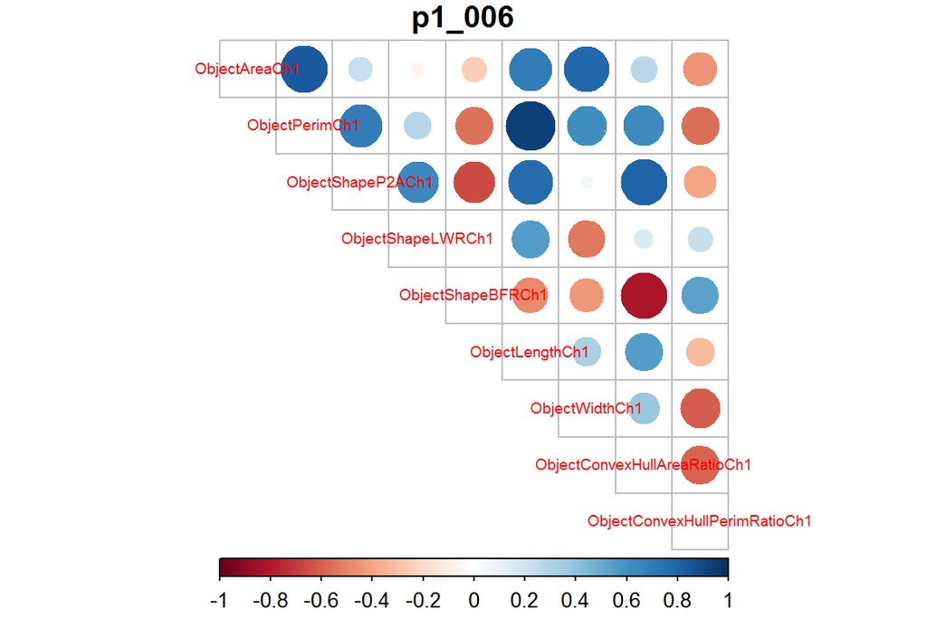

```r
# visualize the correlation matrix
corrplot(cor_matrix_p1_006, method="circle", type = "upper", cl.pos = "b", tl.pos = "d", tl.cex = 0.6, title = "p1_006", mar=c(0,0,1,0))
```

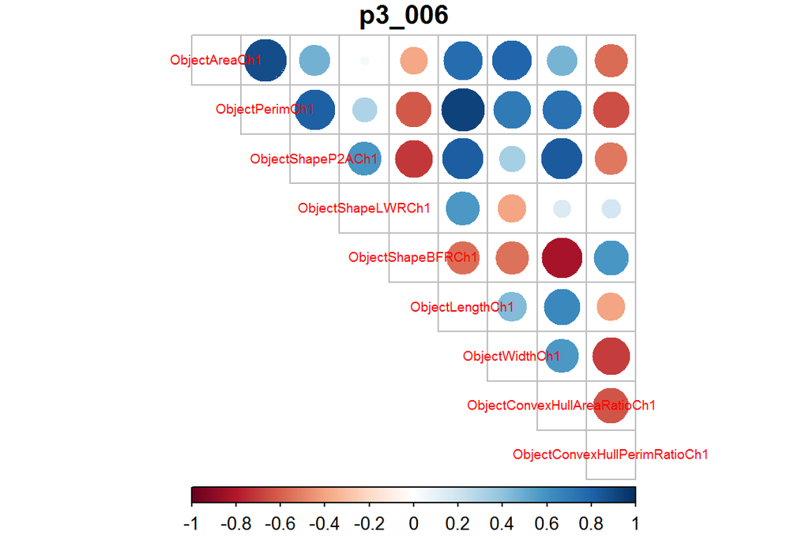

```r
corrplot(cor_matrix_p3_006, method="circle", type = "upper", cl.pos = "b", tl.pos = "d", tl.cex = 0.6, title = "p3_006", mar=c(0,0,1,0))
```

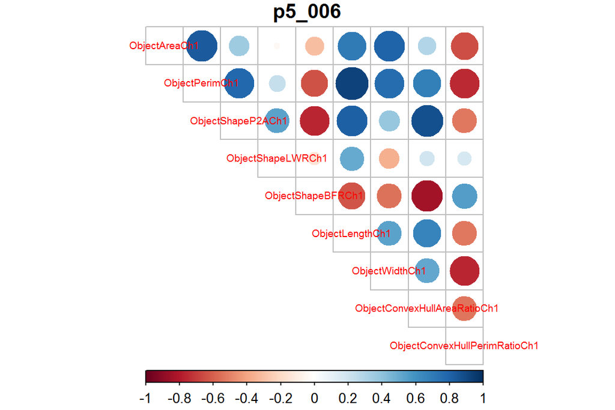

```r
corrplot(cor_matrix_p5_006, method="circle", type = "upper", cl.pos = "b", tl.pos = "d", tl.cex = 0.6, title = "p5_006", mar=c(0,0,1,0))
```

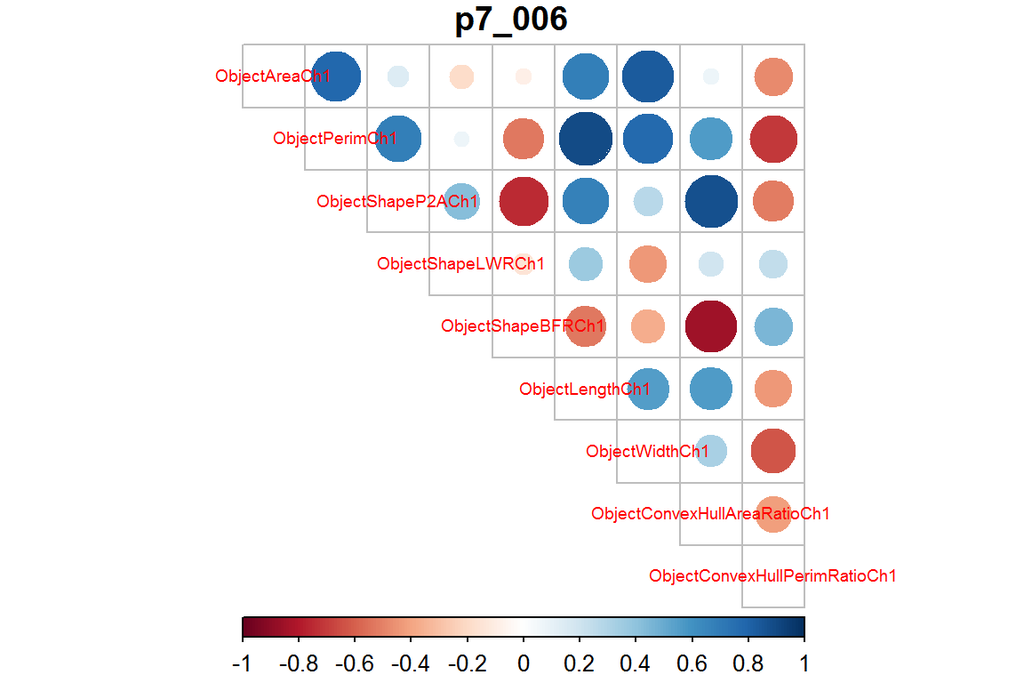

```r
corrplot(cor_matrix_p7_006, method="circle", type = "upper", cl.pos = "b", tl.pos = "d", tl.cex = 0.6, title = "p7_006", mar=c(0,0,1,0))
```

```r
# regression model with multiple explanatory variables
my_model_p1_006 <- lm(p1_006$ObjectAreaCh1 ~ p1_006$ObjectPerimCh1 + p1_006$ObjectLengthCh1 + p1_006$ObjectWidthCh1, data = p1_006)

# print out a summary of the model
summary(my_model_p1_006)
```

```
##
## Call:
## lm(formula = p1_006$ObjectAreaCh1 ~ p1_006$ObjectPerimCh1 + p1_006$ObjectLengthCh1 +
##     p1_006$ObjectWidthCh1, data = p1_006)
##
## Residuals:
##     Min      1Q  Median      3Q     Max
## -2187.1  -101.0    12.5   104.8  5164.4
##
## Coefficients:
##                         Estimate Std. Error t value Pr(>|t|)
## (Intercept)            -807.7454    10.8405  -74.51   <2e-16 ***
## p1_006$ObjectPerimCh1    -0.6237     0.2874   -2.17     0.03 *
## p1_006$ObjectLengthCh1   14.4015     0.6189   23.27   <2e-16 ***
## p1_006$ObjectWidthCh1    35.2690     0.5804   60.77   <2e-16 ***
## ---
## Signif. codes:  0 '***' 0.001 '**' 0.01 '*' 0.05 '.' 0.1 ' ' 1
##
## Residual standard error: 247.2 on 8519 degrees of freedom
## Multiple R-squared:  0.8308, Adjusted R-squared:  0.8307
## F-statistic: 1.394e+04 on 3 and 8519 DF,  p-value: < 2.2e-16
```

```r
# The relationship between the chosen explanatory variables and the target variable is statistically significant for variable p1_006$ObjectLengthCh1 and p1_006$ObjectWidthCh1 ('***' 0.001), and for p1_006$ObjectPerimCh1 ('*' 0.05). Multiple R squared of the model is 0.8307, which is high thus linear model explains well this data. (Ref Wikipedia: In statistics, the coefficient of multiple correlation is a measure of how well a given variable can be predicted using a linear function of a set of other variables).

# Diagnostic plots using the plot() function. Residuals vs Fitted values, Normal QQ-plot and Residuals vs Leverage, plots 1, 2 and 5. Some outliers seen from diagnostic plots, e.g. in Normal Q-Q plot data not linear in the beginnig and at the end points.
#par(mfrow = c(2,2))
```

Data was further analysed using linear regression model for passage 1 data (p1). The relationship between the chosen explanatory variables and the target variable is statistically significant for variable ObjectLengthCh1 and ObjectWidthCh1 (0.001), and for ObjectPerimCh1 (0.05). Multiple R squared of the model is 0.8308, which is high thus linear model explains well this data.

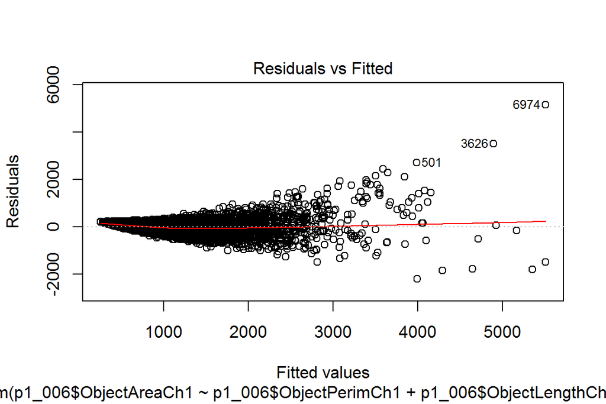

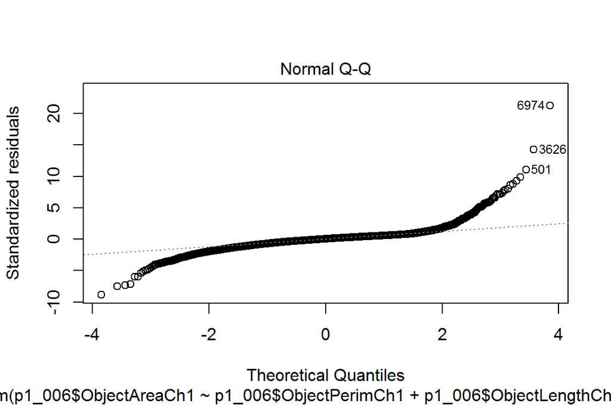

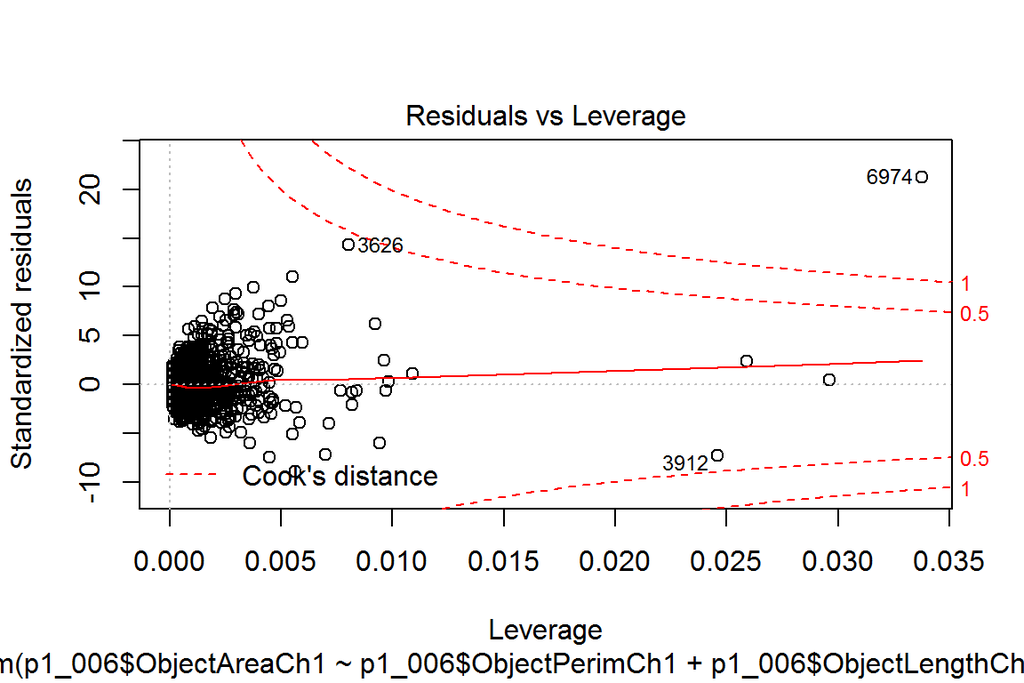

```r
plot(my_model_p1_006, which = c(1,2,5))
```

```r
# principal component analysis (PCA) for standardized data for p1 data

# standardize the variables
p1_006_std <- scale(p1_006)

# perform principal component analysis (with the SVD method)
pca_p1_006 <- prcomp(p1_006_std)

# draw a biplot of the principal component representation and the original variables
#biplot(pca_p1_006, choices = 1:2, cex = c(0.8, 1), col = c("grey40", "deeppink2"))

# create and print out a summary of pca_p1_006
s <- summary(pca_p1_006)
s
```

```
## Importance of components:
##                           PC1    PC2    PC3     PC4     PC5     PC6
## Standard deviation     2.2092 1.4656 1.1246 0.64640 0.41253 0.25656
## Proportion of Variance 0.5423 0.2387 0.1405 0.04643 0.01891 0.00731
## Cumulative Proportion  0.5423 0.7809 0.9215 0.96789 0.98680 0.99412
##                            PC7     PC8     PC9
## Standard deviation     0.18029 0.13245 0.05392
## Proportion of Variance 0.00361 0.00195 0.00032
## Cumulative Proportion  0.99773 0.99968 1.00000
```

```r
# rounded percetanges of variance captured by each PC
pca_pr <- round(100*s$importance[2, ], digits = 1)

# print out the percentages of variance
pca_pr
```

```
##  PC1  PC2  PC3  PC4  PC5  PC6  PC7  PC8  PC9
## 54.2 23.9 14.1  4.6  1.9  0.7  0.4  0.2  0.0
```

```r
# create object pc_lab to be used as axis labels
pc_lab <- paste0(names(pca_pr), " (", pca_pr, "%)")
```

Data was further analysed using dimensionality reduction techniques, principal component analysis (PCA) for passage 1 data (p1). PC1 explains 54.2% and PC2 23.9% of the variance.

- ObjectPerimCh1 and ObjectShapeBFRCh1 are linear to PC1 and pointing to opposite directions.
- Perpendicular to these parameters is ObjectShapeLWRCh1, which is pointing to an increasing PC2.

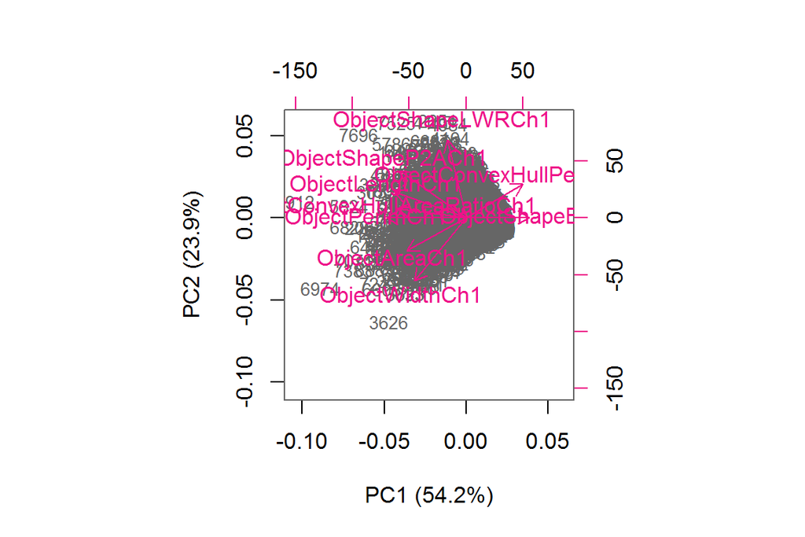

```r
# draw a biplot
biplot(pca_p1_006, cex = c(0.8, 1), col = c("grey40", "deeppink2"), xlab = pc_lab[1], ylab = pc_lab[2])
```

```r
# principal component analysis (PCA) for standardized data and subset of parameters for p1 data

# column names to keep in the dataset
keep_columns <- c("ObjectAreaCh1", "ObjectPerimCh1", "ObjectShapeP2ACh1", "ObjectLengthCh1", "ObjectWidthCh1", "ObjectConvexHullAreaRatioCh1", "ObjectConvexHullPerimRatioCh1")

# select the 'keep_columns' to create a new dataset
p1_006_size_shape <- select(p1_006, one_of(keep_columns))

# standardize the variables
p1_006_std <- scale(p1_006_size_shape)

# perform principal component analysis (with the SVD method)
pca_p1_006 <- prcomp(p1_006_std)

# create and print out a summary of pca_p1_006
s <- summary(pca_p1_006)
s
```

```
## Importance of components:
##                           PC1    PC2    PC3     PC4     PC5     PC6
## Standard deviation     2.0820 1.1781 0.9476 0.53948 0.23946 0.16185
## Proportion of Variance 0.6192 0.1983 0.1283 0.04158 0.00819 0.00374
## Cumulative Proportion  0.6192 0.8175 0.9458 0.98734 0.99553 0.99927
##                            PC7
## Standard deviation     0.07155
## Proportion of Variance 0.00073
## Cumulative Proportion  1.00000
```

```r
# rounded percetanges of variance captured by each PC
pca_pr <- round(100*s$importance[2, ], digits = 1)

# print out the percentages of variance
pca_pr
```

```
##  PC1  PC2  PC3  PC4  PC5  PC6  PC7
## 61.9 19.8 12.8  4.2  0.8  0.4  0.1
```

```r
# create object pc_lab to be used as axis labels
pc_lab <- paste0(names(pca_pr), " (", pca_pr, "%)")

# draw a biplot
# Data was further analysed using dimensionality reduction techniques, principal component analysis (PCA) for subset of passage 1 data (p1). PC1 explains 61.9% and PC2 19.8% of the variance.
```

Data was further analysed using dimensionality reduction techniques, principal component analysis (PCA) for a subset of cell features for passages 1, 3, 5 and 7 data (p1, p3, p5 and p7).

Similar trends were observed in all passage data

- ObjectPerimCh1 and ObjectConvexHullPerimRatioCh1 are linear to PC1 and pointing to opposite directions.
- Strong correlations are found between ObjectPerimCh1 and ObjectLengthCh1, ObjectAreaCh1 and ObjectWidthCh1, ObjectShapeP2ACh1 and ObjectConvexHullAreaRatioCh1.

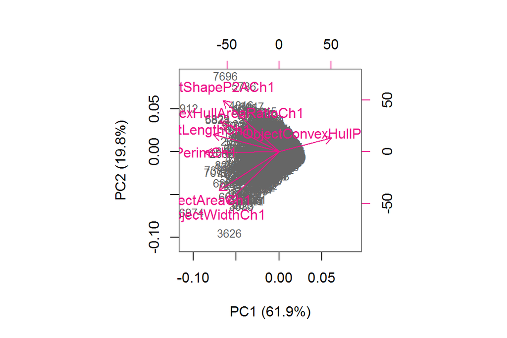

```r
biplot(pca_p1_006, cex = c(0.8, 1), col = c("grey40", "deeppink2"), xlab = pc_lab[1], ylab = pc_lab[2])
```

```r
# principal component analysis (PCA) for standardized data and subset of parameters for p3 data

# column names to keep in the dataset
keep_columns <- c("ObjectAreaCh1", "ObjectPerimCh1", "ObjectShapeP2ACh1", "ObjectLengthCh1", "ObjectWidthCh1", "ObjectConvexHullAreaRatioCh1", "ObjectConvexHullPerimRatioCh1")

# select the 'keep_columns' to create a new dataset
p3_006_size_shape <- select(p3_006, one_of(keep_columns))

# standardize the variables
p3_006_std <- scale(p3_006_size_shape)

# perform principal component analysis (with the SVD method)
pca_p3_006 <- prcomp(p3_006_std)

# create and print out a summary of pca_p3_006
s <- summary(pca_p3_006)
s
```

```
## Importance of components:
##                           PC1    PC2    PC3     PC4     PC5     PC6
## Standard deviation     2.2241 0.9951 0.8428 0.51942 0.23462 0.15113
## Proportion of Variance 0.7066 0.1415 0.1015 0.03854 0.00786 0.00326
## Cumulative Proportion  0.7066 0.8481 0.9496 0.98812 0.99598 0.99924
##                            PC7
## Standard deviation     0.07283
## Proportion of Variance 0.00076
## Cumulative Proportion  1.00000
```

```r
# rounded percetanges of variance captured by each PC
pca_pr <- round(100*s$importance[2, ], digits = 1)

# print out the percentages of variance
pca_pr
```

```
##  PC1  PC2  PC3  PC4  PC5  PC6  PC7
## 70.7 14.1 10.1  3.9  0.8  0.3  0.1
```

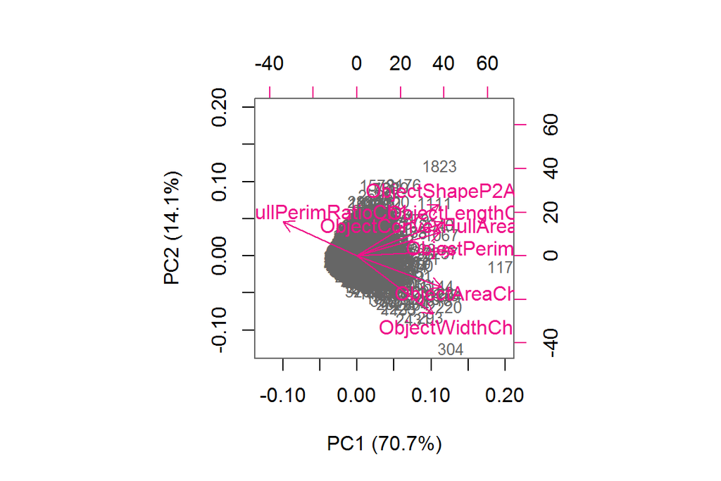

```r
# create object pc_lab to be used as axis labels
pc_lab <- paste0(names(pca_pr), " (", pca_pr, "%)")

# draw a biplot
# Data was further analysed using dimensionality reduction techniques, principal component analysis (PCA) for subset of passage 3 data (p3). PC1 explains 70.7% and PC2 14.1% of the variance.
biplot(pca_p3_006, cex = c(0.8, 1), col = c("grey40", "deeppink2"), xlab = pc_lab[1], ylab = pc_lab[2])
```

```r
# principal component analysis (PCA) for standardized data and subset of parameters for p5 data

# column names to keep in the dataset
keep_columns <- c("ObjectAreaCh1", "ObjectPerimCh1", "ObjectShapeP2ACh1", "ObjectLengthCh1", "ObjectWidthCh1", "ObjectConvexHullAreaRatioCh1", "ObjectConvexHullPerimRatioCh1")

# select the 'keep_columns' to create a new dataset
p5_006_size_shape <- select(p5_006, one_of(keep_columns))

# standardize the variables
p5_006_std <- scale(p5_006_size_shape)

# perform principal component analysis (with the SVD method)
pca_p5_006 <- prcomp(p5_006_std)

# create and print out a summary of pca_p5_006
s <- summary(pca_p5_006)
s
```

```
## Importance of components:
##                           PC1    PC2     PC3     PC4     PC5     PC6
## Standard deviation     2.2239 1.0685 0.74372 0.51528 0.20973 0.20424
## Proportion of Variance 0.7065 0.1631 0.07902 0.03793 0.00628 0.00596
## Cumulative Proportion  0.7065 0.8696 0.94862 0.98655 0.99284 0.99880
##                            PC7
## Standard deviation     0.09172
## Proportion of Variance 0.00120
## Cumulative Proportion  1.00000
```

```r
# rounded percetanges of variance captured by each PC
pca_pr <- round(100*s$importance[2, ], digits = 1)

# print out the percentages of variance
pca_pr
```

```
##  PC1  PC2  PC3  PC4  PC5  PC6  PC7
## 70.7 16.3  7.9  3.8  0.6  0.6  0.1
```

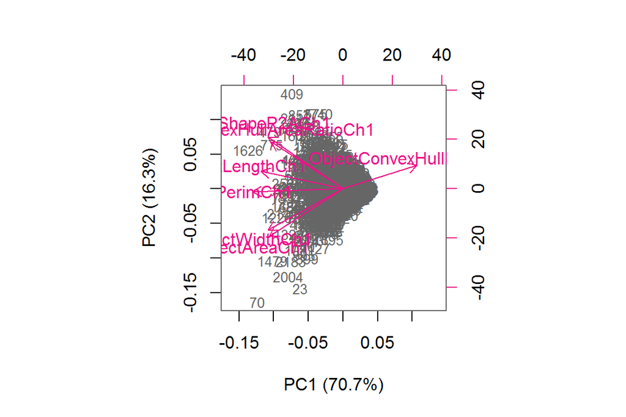

```r
# create object pc_lab to be used as axis labels
pc_lab <- paste0(names(pca_pr), " (", pca_pr, "%)")

# draw a biplot
# Data was further analysed using dimensionality reduction techniques, principal component analysis (PCA) for subset of passage 5 data (p5). PC1 explains 70.7% and PC2 16.3% of the variance.
biplot(pca_p5_006, cex = c(0.8, 1), col = c("grey40", "deeppink2"), xlab = pc_lab[1], ylab = pc_lab[2])
```

```r
# principal component analysis (PCA) for standardized data and subset of parameters for p7 data

# column names to keep in the dataset
keep_columns <- c("ObjectAreaCh1", "ObjectPerimCh1", "ObjectShapeP2ACh1", "ObjectLengthCh1", "ObjectWidthCh1", "ObjectConvexHullAreaRatioCh1", "ObjectConvexHullPerimRatioCh1")

# select the 'keep_columns' to create a new dataset
p7_006_size_shape <- select(p7_006, one_of(keep_columns))

# standardize the variables
p7_006_std <- scale(p7_006_size_shape)

# perform principal component analysis (with the SVD method)
pca_p7_006 <- prcomp(p7_006_std)

# create and print out a summary of pca_p7_006
s <- summary(pca_p7_006)
s
```

```
## Importance of components:
##                           PC1    PC2     PC3     PC4     PC5     PC6
## Standard deviation     2.1128 1.2170 0.79143 0.55190 0.26075 0.20730
## Proportion of Variance 0.6377 0.2116 0.08948 0.04351 0.00971 0.00614
## Cumulative Proportion  0.6377 0.8493 0.93877 0.98228 0.99200 0.99813
##                            PC7
## Standard deviation     0.11427
## Proportion of Variance 0.00187
## Cumulative Proportion  1.00000
```

```r
# rounded percetanges of variance captured by each PC
pca_pr <- round(100*s$importance[2, ], digits = 1)

# print out the percentages of variance
pca_pr
```

```
##  PC1  PC2  PC3  PC4  PC5  PC6  PC7
## 63.8 21.2  8.9  4.4  1.0  0.6  0.2
```

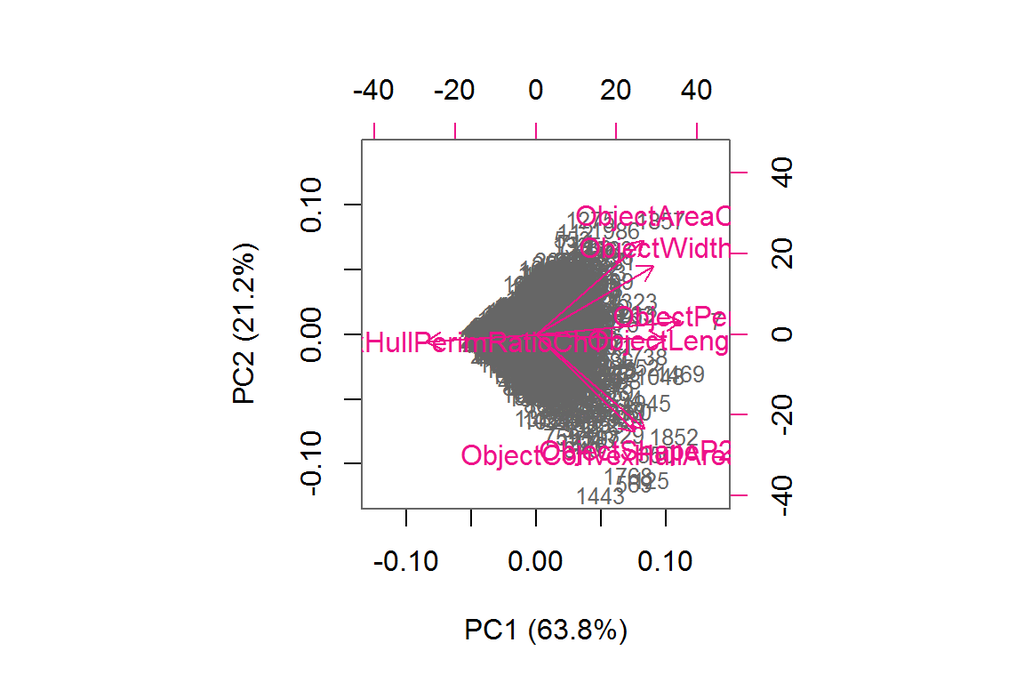

```r
# create object pc_lab to be used as axis labels
pc_lab <- paste0(names(pca_pr), " (", pca_pr, "%)")

# draw a biplot
# Data was further analysed using dimensionality reduction techniques, principal component analysis (PCA) for subset of passage 7 data (p7). PC1 explains 63.8% and PC2 21.2% of the variance.
biplot(pca_p7_006, cex = c(0.8, 1), col = c("grey40", "deeppink2"), xlab = pc_lab[1], ylab = pc_lab[2])
```